# Reproducible Research - Peer Assignment 1

## Loading and preprocessing the data

Load the data (i.e. read.csv())

Process/transform the data (if necessary) into a format suitable for your analysis

```r
library(dplyr)
```

```r
library(ggplot2)

activity <- read.csv("./activity.csv")
```

## What is mean total number of steps taken per day?

1. Calculate the total number of steps taken per day
2. Make a histogram of the total number of steps taken each day
3. Calculate and report the mean and median of the total number of steps taken per day

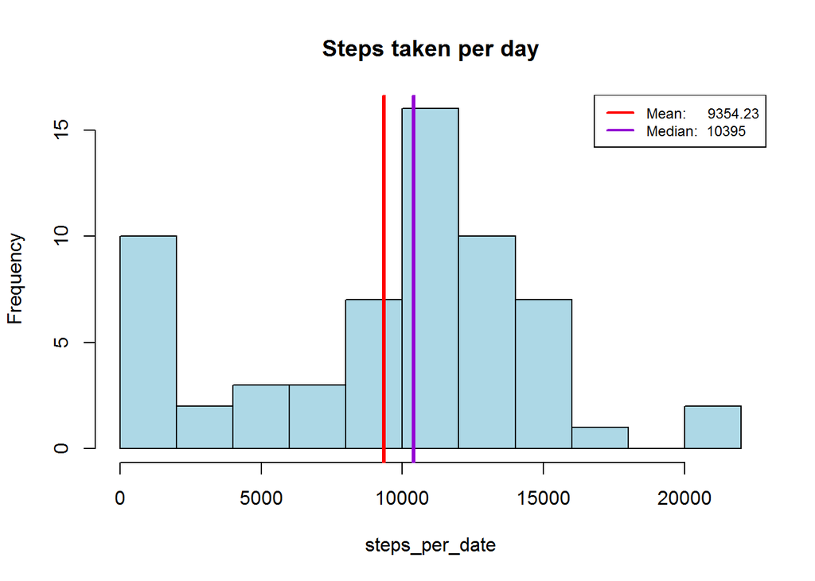

```r
# Calcualate steps taken per day
activity_by_date <- group_by(activity, date)
steps_per_date <- summarize(activity_by_date, steps_per_date = sum(steps, na.rm = T))

# Plot a histogram of steps taken per day
with(steps_per_date, hist(steps_per_date, main = "Steps taken per day", col = "light blue", breaks = 10))

# Calculate and report the mean and median of the total number of steps taken per day
mean_steps_per_day <- round(mean(steps_per_date$steps_per_date), digits = 2)
median_steps_per_day <- round(median(steps_per_date$steps_per_date), digits = 2)
abline(v=mean_steps_per_day, lwd = 3, col = 'red')
abline(v=median_steps_per_day, lwd = 3, col = 'dark violet')

#create legend
legend("topright", lty = 1, lwd = 2, col = c("red", "dark violet"), cex = 0.75,
       legend = c(paste('Mean:    ', mean_steps_per_day),
                  paste('Median: ', median_steps_per_day)))
```

## What is the average daily activity pattern?

1. Make a time series plot (i.e. type = “l”) of the 5-minute interval (x-axis) and the average number of steps taken, averaged across all days (y-axis)
2. Find which 5-minute interval, on average across all the days in the dataset, contains the maximum number of steps

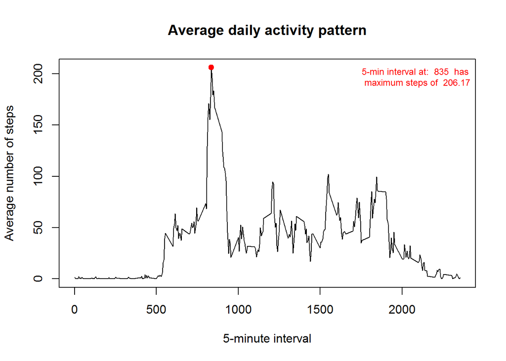

```r
# Calculate average steps taken per 5 min interval
steps_by_interval <- group_by(activity, interval)
steps_by_interval <- summarise(steps_by_interval, avg_steps_by_interval =
                                   mean(steps, na.rm = T))

# Plot time series average of steps taken Vs interval
with(steps_by_interval, plot(interval, avg_steps_by_interval, type = "l",
                             main = "Average daily activity pattern",
                             xlab = "5-minute interval",
                             ylab = "Average number of steps"))

# Calculate and report which interval has maximum number of average steps
tmp <- steps_by_interval[steps_by_interval$avg_steps_by_interval==max(steps_by_interval$avg_steps_by_interval), ]
points(tmp$interval, tmp$avg_steps_by_interval, col = "red", pch = 19)
legend_text <- paste("5-min interval at: ", tmp$interval, " has \n",
                     "maximum steps of ", round(tmp$avg_steps_by_interval, digits = 2))
legend("topright", legend = legend_text, text.col = "red", bty = "n", cex = 0.75)
```

## Imputing missing values

1. Calculate and report the total number of missing values in the dataset (i.e. the total number of rows with NAs)

```r
print_text <- paste("total records having NA: ", table(complete.cases(activity))[1])
print(print_text)
```

```
## [1] "total records having NA:  2304"
```

```r
print_text <- paste("Steps column having NA: ", table(is.na(activity$steps))[2])
print(print_text)
```

```
## [1] "Steps column having NA:  2304"
```

```r
print_text <- paste("Date column having NA: ", table(is.na(activity$date))[2])
print(print_text)
```

```
## [1] "Date column having NA:  NA"
```

```r
print_text <- paste("Interval column having NA: ", table(is.na(activity$interval))[2])
print(print_text)
```

```
## [1] "Interval column having NA:  NA"
```

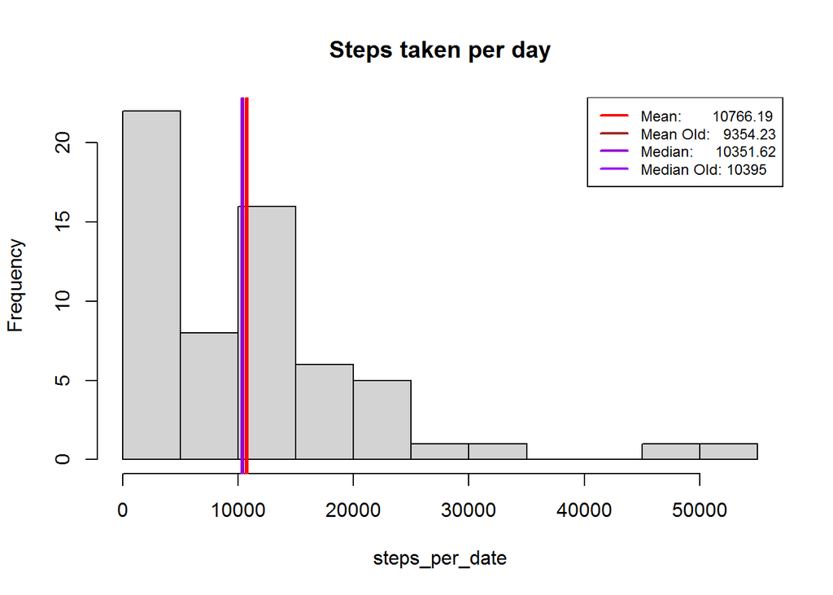

```r
# Function to replace NA with a given value
replaceNA <- function(x,y){
    if(is.na(x)){

        return(y)
    }
    return(x)
}

# Calcualte average steps per interval
avg_steps_by_interval <- aggregate(x = activity$steps , by = list(activity$interval), FUN = mean ,na.rm=TRUE)
names(avg_steps_by_interval) <- c("interval","avg_steps")
merged_activity <- merge(x = activity, y = avg_steps_by_interval, by = "interval", all.x = TRUE)

# Replace steps with "NA" value with average per inerval calculated above
activity$steps2 <- mapply(replaceNA, merged_activity$steps, merged_activity$avg_steps)

# Plot histogram along with new mean and median Vs. old mean and median
activity_by_date2 <- group_by(activity, date)
steps_per_date2 <- summarize(activity_by_date2, steps_per_date = sum(steps2, na.rm = T))
mean_steps_per_day2 <- round(mean(steps_per_date2$steps_per_date), digits = 2)
median_steps_per_day2 <- round(median(steps_per_date2$steps_per_date), digits = 2)
with(steps_per_date2, hist(steps_per_date, main = "Steps taken per day", col = "light gray", breaks = 10))

abline(v=mean_steps_per_day2, lwd = 3, col = 'red')
abline(v=median_steps_per_day2, lwd = 3, col = 'dark violet')

legend("topright", lty = 1, lwd = 2, col = c("red", "brown", "dark violet", "purple"),
       cex = 0.75, legend = c(paste('Mean:      ', mean_steps_per_day2),
                              paste('Mean Old:  ', mean_steps_per_day),
                              paste('Median:    ', median_steps_per_day2),
                              paste('Median Old:', median_steps_per_day)))
```

## Differences in activity patterns between weekdays and weekends?

For this part the weekdays() function may be of some help here. Use the dataset with the filled-in missing values for this part.

1. Create a new factor variable in the dataset with two levels - “weekday” and “weekend” indicating whether a given date is a weekday or weekend day.
2. Make a panel plot containing a time series plot (i.e. type = “l”) of the 5-minute interval (x-axis) and the average number of steps taken, averaged across all weekday days or weekend days (y-axis). See the README file in the GitHub repository to see an example of what this plot should look like using simulated data

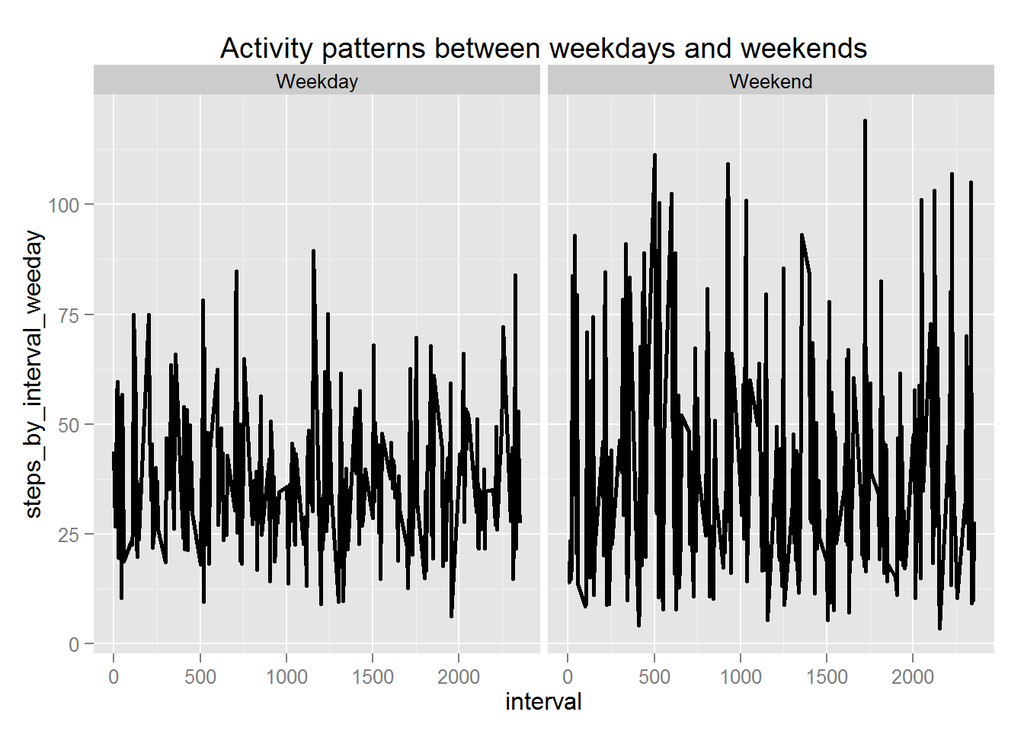

```r
# Find whether a date is weekday or weekend
activity$date <- as.Date(activity$date)
activity$weekday <- as.factor(ifelse(weekdays(activity$date) %in% c("Saturday","Sunday"),
                                     "Weekend", "Weekday"))

# Find steps by time interval and weekday (weekdays or weekend)
activity_by_interval_weekday <- group_by(activity, interval, weekday)
activity_by_interval_weekday <- summarise(activity_by_interval_weekday,
                                          steps_by_interval_weeday = mean(steps2, na.rm = T));

# plot a time series of aggragsteps
plot_obj <- ggplot(activity_by_interval_weekday,aes(interval, steps_by_interval_weeday)) +
    ggtitle("Activity patterns between weekdays and weekends") +
    facet_grid(. ~ weekday) +
    geom_line(size = 1)

plot_obj
```